# HLA supertypes Project

Published

September 29, 2025

```r
# Load libraries
library(dplyr)
library(readr)
library(tidyr)
library(tibble)
library(ggplot2)
```

### 1. HLA-A 5×3 Contingency Table

```r
# Read in HLA_A data
df <- read_csv("hla_a_supertypes_raw_numbers_by_group(in).csv") %>%
      select(-`...1`) %>%
      # Convert long data into contigency table
      pivot_wider(names_from = immune,
                  values_from = Freq,
                  values_fill = 0 ) %>%
      column_to_rownames("V1") %>%
      as.matrix()

df
```

```
        Immunosuppressed High Low
A01                   12    5   9
A01 A24                2    1   0
A02                   10    6   6
A03                   13   13   9
A24                    6    3   6
```

**Fisher’s exact test** was used on this 5×3 table to test whether the distribution of HLA-A supertypes differed across immune groups, since some cell counts were less than 5. The overall p = 0.82 indicated no significant difference.

```r
# Fisher exact test
fisher.test(df, simulate.p.value = TRUE)
```

```
    Fisher's Exact Test for Count Data with simulated p-value (based on
    2000 replicates)

data:  df
p-value = 0.8251
alternative hypothesis: two.sided
```

**Residual plots**

Residuals show how much the actual counts of HLA-A supertypes differ from what we would expect if the distribution were the same across all immune groups. Positive values mean more than expected, negative values mean fewer. The dashed red lines at ±2 are the usual cutoff for what we’d consider a “large” difference. Since all the bars stay within these red lines, the differences we see are small and not strong enough to be meaningful. For example, the A03 type looks a little higher in the High group, but it’s still within the range of normal variation, it’s more likely due to random variation in your current sample.

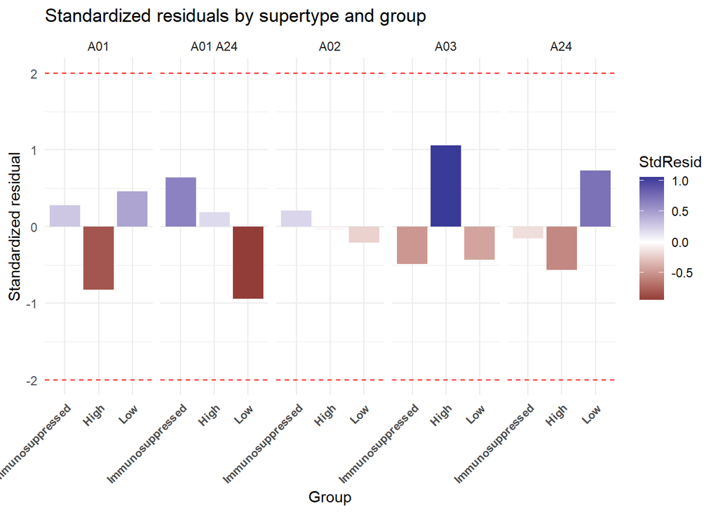

```r
# Residual plot
chi <- chisq.test(df)
res <- as.data.frame(as.table(chi$residuals))
names(res) <- c("Supertype", "Group", "StdResid")

ggplot(res, aes(x = Group, y = StdResid, fill = StdResid)) +
  geom_col() +
  facet_wrap(~Supertype, nrow = 1) +
  geom_hline(yintercept = c(-2, 2), linetype = "dashed", color = "red") +
  labs(title = "Standardized residuals by supertype and group",
       y = "Standardized residual") +
  scale_fill_gradient2(midpoint = 0) +
  theme_minimal() +
  theme(axis.text.x = element_text(angle = 45, hjust = 1, size = 8,face = "bold"))
```

### 2. HLA-B 7×3 Contingency Table

```r
# Read in HLA-B data
df2 <- read_csv("hla_b_supertypes_raw_numbers_by_group(in).csv") %>%
       select(-`...1`) %>%
       # Convert long data into contigency table
       pivot_wider(names_from = immune,
                   values_from = Freq,
                   values_fill = 0 ) %>%
                   column_to_rownames("V1") %>%
                   as.matrix()

df2
```

```
             Immunosuppressed High Low
B07                        11    9  10
B08                         6    3   2
B27                         8    9   5
B44                         9   10   8
B62                         4    0   0
Unclassified                4    0   3
B58                         0    1   3
```

```r
# Fisher exact test
fisher.test(df2, simulate.p.value = TRUE)
```

```
    Fisher's Exact Test for Count Data with simulated p-value (based on
    2000 replicates)

data:  df2
p-value = 0.2144
alternative hypothesis: two.sided
```

**Residual plots**

The HLA-B plot, similar to HLA-A, shows no large differences since all bars are within the red limits.

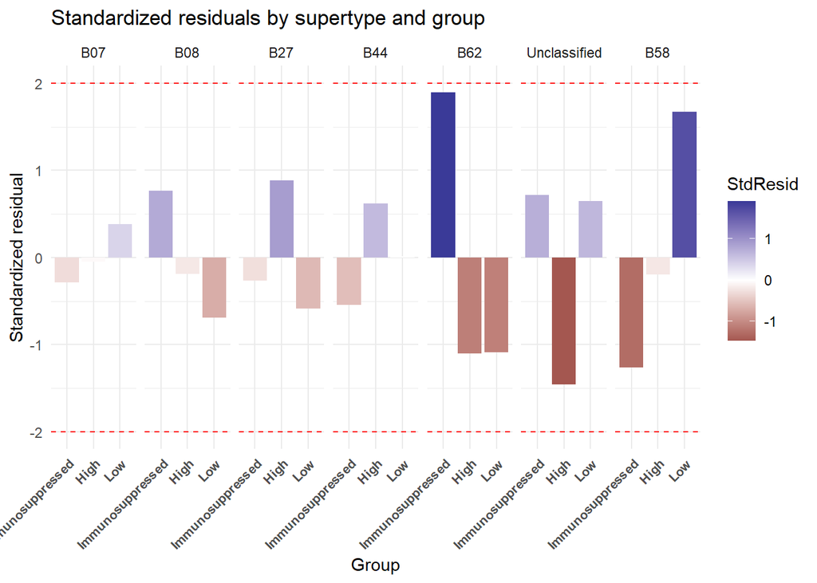

```r
# Residual plot
# Residual plot
chi <- chisq.test(df2)
res <- as.data.frame(as.table(chi$residuals))
names(res) <- c("Supertype", "Group", "StdResid")

ggplot(res, aes(x = Group, y = StdResid, fill = StdResid)) +
  geom_col() +
  facet_wrap(~Supertype, nrow = 1) +
  geom_hline(yintercept = c(-2, 2), linetype = "dashed", color = "red") +
  labs(title = "Standardized residuals by supertype and group",
       y = "Standardized residual") +
  scale_fill_gradient2(midpoint = 0) +
  theme_minimal() +
  theme(axis.text.x = element_text(angle = 45, hjust = 1, size = 8,face = "bold"))
```